# Image Classifiers: 3 Scenes

#### The dataset consists of 3 sets of images: Coast (360 of images), Forest (328 of images), Highway (260 of images)

The 3-scenes dataset was created by sampling the 8-scenes dataset from Oliva and Torralba’s 2001 paper, Modeling the shape of the scene: a holistic representation of the spatial envelope.

[figure not shown]

```python
URL = './image-classification/3scenes'
```

```python
from PIL import Image
import numpy as np
import pandas as pd

from sklearn.neighbors import KNeighborsClassifier
from sklearn.linear_model import LogisticRegression
from sklearn.ensemble import RandomForestClassifier
from sklearn.model_selection import train_test_split
from sklearn.metrics import classification_report
from sklearn.preprocessing import LabelEncoder

from keras.models import Sequential
from keras.layers.convolutional import Conv2D
from keras.layers.convolutional import MaxPooling2D
from keras.layers.core import Activation
from keras.layers.core import Flatten
from keras.layers.core import Dense
from keras.optimizers import Adam
from keras.preprocessing import image
from keras.preprocessing.image import ImageDataGenerator
```

```python
import os
import matplotlib.pyplot as plt
import matplotlib.image as mpimg
import seaborn as sns
%matplotlib inline

from time import sleep
```

```python
dirs = ['coast', 'forest', 'highway']
```

```python
df = pd.DataFrame(columns=['directory_index', 'name', 'RMean', 'GMean', 'BMean', 'RStd', 'GStd', 'BStd'])
```

```python
def basicFeatures(img):
    R, G, B = img.split()
    return np.mean(R), np.mean(G), np.mean(B), np.std(R), np.std(G), np.std(B)
```

```python
for i in range(0, len(dirs)):
    imgs = os.listdir(URL+'/'+dirs[i])
    for img in imgs:
        image = Image.open(URL + '/' + dirs[i] + '/' + img)
        df.loc[len(df)] = [i, img]+ list(basicFeatures(image))
```

```python
len(df)
```

```
948
```

## Data distribution

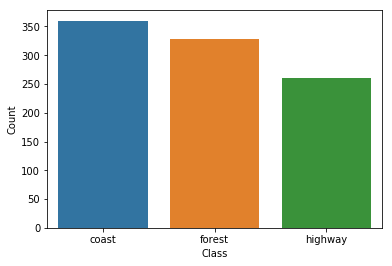

```python
sns.barplot(x=dirs, y=df.groupby('directory_index').count()['name'])
plt.xlabel('Class')
plt.ylabel('Count')
```

###### The graph shows that the data is pretty evenly distributed

```python
Image.open('./image-classification/3scenes/coast/coast_arnat59.jpg').size
```

```
(256, 256)
```

##### The images are of the dimension 256 x 256

## Feature Extraction

###### Extracting some basic RGB features like mean and standard deviation

```python
df['directory_index'] = [int(i) for i in df['directory_index']]
```

```python
df.head()
```

|  | directory_index | name | RMean | GMean | BMean | RStd | GStd | BStd |
| --- | --- | --- | --- | --- | --- | --- | --- | --- |
| 0 | 0 | coast_arnat59.jpg | 105.667969 | 112.080811 | 130.529739 | 73.060648 | 70.799809 | 77.694478 |
| 1 | 0 | coast_art1130.jpg | 99.947098 | 123.478622 | 162.072464 | 28.508838 | 32.284471 | 49.888721 |
| 2 | 0 | coast_art294.jpg | 104.230011 | 109.082932 | 123.283401 | 52.511729 | 43.139999 | 60.146443 |
| 3 | 0 | coast_art487.jpg | 207.031967 | 207.346863 | 214.176941 | 34.095587 | 32.120136 | 39.276893 |
| 4 | 0 | coast_bea1.jpg | 95.336731 | 168.728561 | 165.017853 | 63.932428 | 60.284912 | 68.425806 |

##### Analysing the distribution of each feature in the three class of images

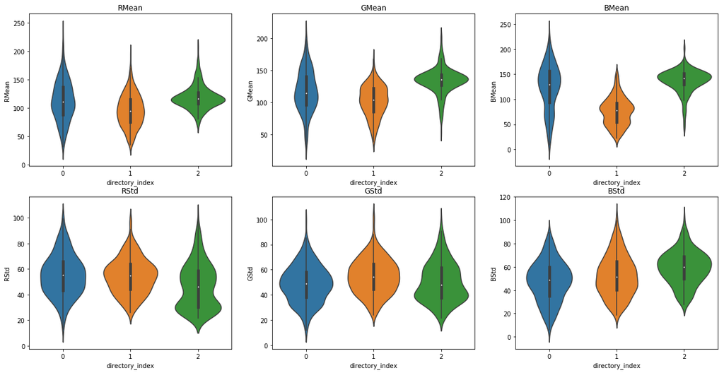

```python
fig, ax = plt.subplots(nrows=2, ncols=3, figsize=(20,10))
sns.violinplot(x='directory_index', y='RMean', data=df, ax=ax[0][0])
ax[0][0].set_title('RMean')
sns.violinplot(x='directory_index', y='GMean', data=df, ax=ax[0][1])
ax[0][1].set_title('GMean')
sns.violinplot(x='directory_index', y='BMean', data=df, ax=ax[0][2])
ax[0][2].set_title('BMean')
sns.violinplot(x='directory_index', y='RStd', data=df, ax=ax[1][0])
ax[1][0].set_title('RStd')
sns.violinplot(x='directory_index', y='GStd', data=df, ax=ax[1][1])
ax[1][1].set_title('GStd')
sns.violinplot(x='directory_index', y='BStd', data=df, ax=ax[1][2])
ax[1][2].set_title('BStd')
```

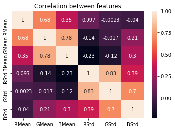

```python
sns.heatmap(df.drop('name',1).drop('directory_index',1).corr(),annot=True)
plt.title('Correlation between features')
```

##### From these graphs it is clear that these features cannot be used independantly for classification. From the heatmap, we can see that they have high correlation. Thus, we can use a model like Logistic Regression for classification

## Simple Classification

##### Let's try to classify these images using a simple Logistic Regression classifier

```python
trainX, testX, trainY, testY = train_test_split(df.drop('name',1).drop('directory_index',1), df['directory_index'],test_size=0.25)

lr = LogisticRegression()
lr.fit(trainX, trainY)
predictions = lr.predict(testX)

print(classification_report(testY, predictions))
```

```
              precision    recall  f1-score   support

           0       0.71      0.76      0.73        86
           1       0.75      0.88      0.81        88
           2       0.80      0.56      0.65        63

   micro avg       0.75      0.75      0.75       237
   macro avg       0.75      0.73      0.73       237
weighted avg       0.75      0.75      0.74       237
```

[output not shown]

##### Let's also try some other models

```python
rfc = RandomForestClassifier(n_estimators=100)
rfc.fit(trainX, trainY)
predictions = rfc.predict(testX)

print(classification_report(testY, predictions))
```

```
              precision    recall  f1-score   support

           0       0.81      0.83      0.82        86
           1       0.84      0.88      0.86        88
           2       0.84      0.76      0.80        63

   micro avg       0.83      0.83      0.83       237
   macro avg       0.83      0.82      0.82       237
weighted avg       0.83      0.83      0.83       237
```

##### Lets try classifying some images

```python
images = ['coast_predict1.jpg','forest_1.jpg','forest_2.jpg','highway_1.jpg']
features = [list(basicFeatures(Image.open(URL + '/' + img))) for img in images]
```

[figure not shown]

```python
fig, ax = plt.subplots(nrows=2, ncols=2, figsize=(20,10))
image = Image.open(URL + '/' + images[0])
ax[0][0].imshow(image)
ax[0][0].set_title(dirs[rfc.predict([features[0]])[0]])
image = Image.open(URL + '/' + images[1])
ax[1][0].imshow(image)
ax[1][0].set_title(dirs[rfc.predict([features[1]])[0]])
image = Image.open(URL + '/' + images[2])
ax[0][1].imshow(image)
ax[0][1].set_title(dirs[rfc.predict([features[2]])[0]])
image = Image.open(URL + '/' + images[3])
ax[1][1].imshow(image)
ax[1][1].set_title(dirs[rfc.predict([features[3]])[0]])
```

##### As we can see, the classifier classifies the images with 80% accuracy which is pretty good considering the lack of identifying features

Other less successful classifiers, Decision Tree, KNN, Ada Boost etc, were removed from the notebook as they weren't needed

## Classification Using a Basic CNN

##### Although the data is very less, let's try to use Convolution Neural Network for classification as it is generally very effective with media

```python
classifier = Sequential()
classifier.add(Conv2D(32, (3, 3), input_shape = (128, 128, 3), activation = 'relu'))
classifier.add(MaxPooling2D(pool_size = (2, 2)))
classifier.add(Flatten())
```

```python
classifier.add(Dense(units = 128, activation = 'relu'))
```

```python
classifier.add(Dense(units = 1, activation = 'sigmoid'))
```

```python
classifier.compile(optimizer = 'adam', loss = 'binary_crossentropy', metrics = ['accuracy'])
```

```python
classifier.summary()
```

```
_________________________________________________________________
Layer (type)                 Output Shape              Param #
=================================================================
conv2d_3 (Conv2D)            (None, 126, 126, 32)      896
_________________________________________________________________
max_pooling2d_3 (MaxPooling2 (None, 63, 63, 32)        0
_________________________________________________________________
flatten_3 (Flatten)          (None, 127008)            0
_________________________________________________________________
dense_6 (Dense)              (None, 128)               16257152
_________________________________________________________________
dense_7 (Dense)              (None, 1)                 129
=================================================================
Total params: 16,258,177
Trainable params: 16,258,177
Non-trainable params: 0
_________________________________________________________________
```

```python
train_datagen = ImageDataGenerator(rescale = 1./255,
shear_range = 0.2,
zoom_range = 0.2,
horizontal_flip = True)

test_datagen = ImageDataGenerator(rescale = 1./255)

training_set = train_datagen.flow_from_directory(URL+'/train',
target_size = (128, 128),
batch_size = 32,
class_mode = 'binary')

test_set = test_datagen.flow_from_directory(URL+'/test',
target_size = (128, 128),
batch_size = 32,
class_mode = 'binary')
```

```
Found 830 images belonging to 3 classes.
Found 118 images belonging to 3 classes.
```

```python
classifier.fit_generator(training_set,
steps_per_epoch = 830,
epochs = 15,
validation_data = test_set,
validation_steps = 118)
```

```
<keras.callbacks.History at 0x1d890de2908>
```

```python
test_image = image.load_img(URL+'/coast_predict1.jpg', target_size = (128, 128))
test_image = image.img_to_array(test_image)
test_image = np.expand_dims(test_image, axis = 0)
result = classifier.predict(test_image)
#training_set.class_indices
if result[0][0] == 1: print('forest')
elif result[0][0] == 2: print('highway')
else: print('coast')
```

```
forest
```

[figure not shown]